# NetworkAnalysis_PositivePsychology

Hyein

2025-04-12

## Descriptive statistics

```r
#import dataset
library(readxl)
PPI_dataset <- read_excel("/Users/hyeinkim/Documents/N741/milestone/PPI_dataset.xlsx")


library(dplyr)
library(tidyr)

PPI_dataset %>%
  summarise(across(everything(), ~ mean(is.na(.) | . == -999) * 100)) %>%
  pivot_longer(cols = everything(),
               names_to = "Variable",
               values_to = "Missing_Percentage") %>%
  mutate(Missing_Percentage = round(Missing_Percentage, 2)) %>%
  arrange(desc(Missing_Percentage))
```

```
## # A tibble: 175 × 2
##    Variable           Missing_Percentage
##    <chr>                           <dbl>
##  1 AHS_PostTotal                       3
##  2 Flourish_PostTotal                  2
##  3 BMPN_Sat_Rel_Post                   2
##  4 BMPN_Sat_Com_Pre                    2
##  5 Usage                               2
##  6 AHS_POST_2                          2
##  7 AHS_POST_4                          2
##  8 Flourish_PreTotal                   1
##  9 CESD_PostTotal                      1
## 10 PANAS_Pos_Post                      1
## # ℹ 165 more rows
```

```r
#missing data handling
# convert "-999" to NA in the dataset
PPI_dataset[PPI_dataset == -999] <- NA

# remove row with NA
PPI_dataset <- na.omit(PPI_dataset)
```

#name categorical variables

```r
PPI_dataset$Income <- factor(PPI_dataset$Income)
PPI_dataset$Sex <- factor(PPI_dataset$Sex)

PPI_dataset$Income <- factor(PPI_dataset$Income,
                             levels = c(1, 2, 3, 4, 5),
                             labels = c("<$9999",
                                        "$10,000–$29,999",
                                        "$30,000–$59,999",
                                        "$60,000–$89,999",
                                        ">$90,000"))

PPI_dataset$Sex <- factor(PPI_dataset$Sex,
                          levels = c(1, 2),
                          labels = c("Male", "Female"))
```

#Basic Descriptive Statistics, Table 1

```r
summary(PPI_dataset[, c("Flourish_PreTotal", "CESD_PreTotal", "AHS_PreTotal",
                 "BMPN_Sat_Aut_Pre","BMPN_Sat_Rel_Pre", "BMPN_Sat_Com_Pre",
                 "PANAS_Pos_Pre", "AGE", "Income", "Sex")])
```

```
##  Flourish_PreTotal CESD_PreTotal     AHS_PreTotal   BMPN_Sat_Aut_Pre
##  Min.   :19.00     Min.   : 0.000   Min.   :14.00   Min.   : 8.00
##  1st Qu.:36.50     1st Qu.: 3.500   1st Qu.:19.50   1st Qu.:13.00
##  Median :41.00     Median : 8.000   Median :22.00   Median :15.00
##  Mean   :39.88     Mean   : 7.843   Mean   :21.73   Mean   :14.65
##  3rd Qu.:44.00     3rd Qu.:11.000   3rd Qu.:24.00   3rd Qu.:16.00
##  Max.   :54.00     Max.   :25.000   Max.   :30.00   Max.   :20.00
##  BMPN_Sat_Rel_Pre BMPN_Sat_Com_Pre PANAS_Pos_Pre        AGE
##  Min.   : 7.0     Min.   : 7.00    Min.   :13.00   Min.   :19.00
##  1st Qu.:15.0     1st Qu.:12.00    1st Qu.:22.00   1st Qu.:21.00
##  Median :16.0     Median :15.00    Median :27.00   Median :22.00
##  Mean   :15.4     Mean   :14.33    Mean   :26.95   Mean   :22.86
##  3rd Qu.:16.0     3rd Qu.:16.00    3rd Qu.:32.00   3rd Qu.:24.00
##  Max.   :20.0     Max.   :20.00    Max.   :48.00   Max.   :34.00
##              Income       Sex
##  <$9999         : 8   Male  :25
##  $10,000–$29,999:30   Female:58
##  $30,000–$59,999:37
##  $60,000–$89,999: 6
##  >$90,000       : 2
##
```

```r
#Mean and SD
library(table1)
table1(~Flourish_PreTotal+CESD_PreTotal+AHS_PreTotal+BMPN_Sat_Aut_Pre+BMPN_Sat_Rel_Pre+BMPN_Sat_Com_Pre+PANAS_Pos_Pre+AGE+Income+Sex, data=PPI_dataset)
```

|  | Overall (N=83) |
| --- | --- |
| Flourish_PreTotal |  |
| Mean (SD) | 39.9 (7.00) |
| Median [Min, Max] | 41.0 [19.0, 54.0] |
| CESD_PreTotal |  |
| Mean (SD) | 7.84 (5.57) |
| Median [Min, Max] | 8.00 [0, 25.0] |
| AHS_PreTotal |  |
| Mean (SD) | 21.7 (3.24) |
| Median [Min, Max] | 22.0 [14.0, 30.0] |
| BMPN_Sat_Aut_Pre |  |
| Mean (SD) | 14.7 (2.28) |
| Median [Min, Max] | 15.0 [8.00, 20.0] |
| BMPN_Sat_Rel_Pre |  |
| Mean (SD) | 15.4 (2.48) |
| Median [Min, Max] | 16.0 [7.00, 20.0] |
| BMPN_Sat_Com_Pre |  |
| Mean (SD) | 14.3 (2.52) |
| Median [Min, Max] | 15.0 [7.00, 20.0] |
| PANAS_Pos_Pre |  |
| Mean (SD) | 27.0 (7.21) |
| Median [Min, Max] | 27.0 [13.0, 48.0] |
| AGE |  |
| Mean (SD) | 22.9 (3.35) |
| Median [Min, Max] | 22.0 [19.0, 34.0] |
| Income |  |
| <$9999 | 8 (9.6%) |
| $10,000–$29,999 | 30 (36.1%) |
| $30,000–$59,999 | 37 (44.6%) |
| $60,000–$89,999 | 6 (7.2%) |
| >$90,000 | 2 (2.4%) |
| Sex |  |
| Male | 25 (30.1%) |
| Female | 58 (69.9%) |

#Correlation among the psychological constructs

```r
library(dplyr)
cor_data <- PPI_dataset %>%
  select(Flourish_PreTotal, CESD_PreTotal, AHS_PreTotal,
         BMPN_Sat_Aut_Pre, BMPN_Sat_Rel_Pre, BMPN_Sat_Com_Pre, PANAS_Pos_Pre)

cor_matrix <- cor(cor_data, use = "complete.obs", method = "pearson")
cor_matrix
```

```
##                   Flourish_PreTotal CESD_PreTotal AHS_PreTotal BMPN_Sat_Aut_Pre
## Flourish_PreTotal         1.0000000    -0.5562166    0.7161300        0.6957561
## CESD_PreTotal            -0.5562166     1.0000000   -0.5203264       -0.4612272
## AHS_PreTotal              0.7161300    -0.5203264    1.0000000        0.7060230
## BMPN_Sat_Aut_Pre          0.6957561    -0.4612272    0.7060230        1.0000000
## BMPN_Sat_Rel_Pre          0.4369726    -0.2154051    0.3015373        0.3849476
## BMPN_Sat_Com_Pre          0.7268609    -0.6445542    0.7275077        0.7379862
## PANAS_Pos_Pre             0.5320593    -0.2989516    0.5360076        0.4502693
##                   BMPN_Sat_Rel_Pre BMPN_Sat_Com_Pre PANAS_Pos_Pre
## Flourish_PreTotal        0.4369726        0.7268609     0.5320593
## CESD_PreTotal           -0.2154051       -0.6445542    -0.2989516
## AHS_PreTotal             0.3015373        0.7275077     0.5360076
## BMPN_Sat_Aut_Pre         0.3849476        0.7379862     0.4502693
## BMPN_Sat_Rel_Pre         1.0000000        0.3709115     0.2173045
## BMPN_Sat_Com_Pre         0.3709115        1.0000000     0.5120808
## PANAS_Pos_Pre            0.2173045        0.5120808     1.0000000
```

```r
library(corrr)
cor_data %>%
  correlate() %>%
  stretch() %>%
  arrange(desc(r))
```

```
## Correlation computed with
## • Method: 'pearson'
## • Missing treated using: 'pairwise.complete.obs'
```

```
## # A tibble: 49 × 3
##    x                 y                     r
##    <chr>             <chr>             <dbl>
##  1 BMPN_Sat_Aut_Pre  BMPN_Sat_Com_Pre  0.738
##  2 BMPN_Sat_Com_Pre  BMPN_Sat_Aut_Pre  0.738
##  3 AHS_PreTotal      BMPN_Sat_Com_Pre  0.728
##  4 BMPN_Sat_Com_Pre  AHS_PreTotal      0.728
##  5 Flourish_PreTotal BMPN_Sat_Com_Pre  0.727
##  6 BMPN_Sat_Com_Pre  Flourish_PreTotal 0.727
##  7 Flourish_PreTotal AHS_PreTotal      0.716
##  8 AHS_PreTotal      Flourish_PreTotal 0.716
##  9 AHS_PreTotal      BMPN_Sat_Aut_Pre  0.706
## 10 BMPN_Sat_Aut_Pre  AHS_PreTotal      0.706
## # ℹ 39 more rows
```

#Figure 1. Heatmap plot

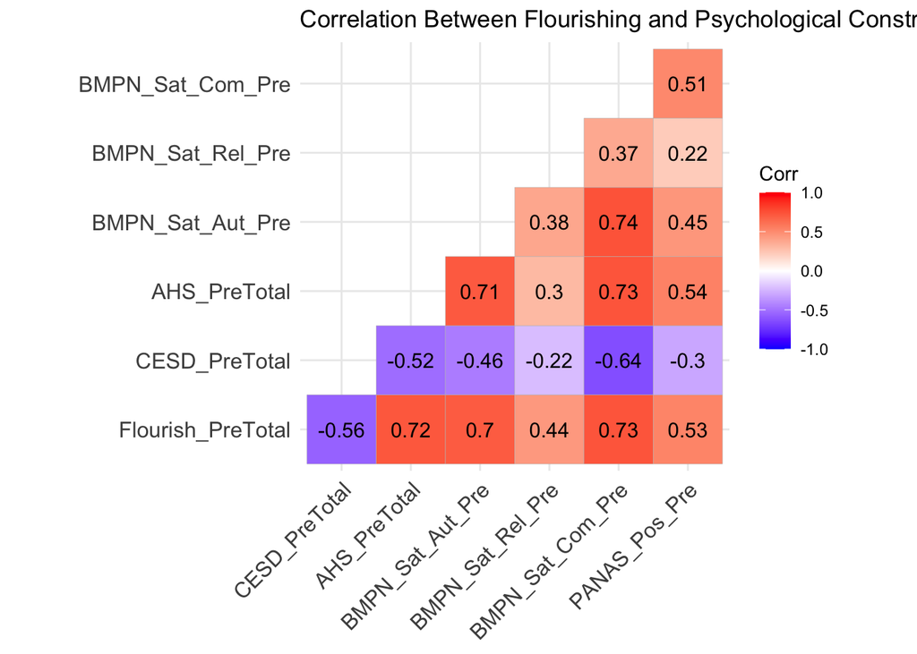

```r
library(ggcorrplot)
ggcorrplot(cor_matrix,
           lab = TRUE,
           type = "lower",
           title = "Correlation Between Flourishing and Psychological Constructs")
```

Network analysis

**Select only PANAS_pro and Flourishing**

```r
library(bootnet)
```

```r
library(qgraph)
library(dplyr)

#Preprocessing

#select PANAS_positive and Flourishing scale

network_data1 <- PPI_dataset[, c("PANAS_1", "PANAS_3", "PANAS_5", "PANAS_9", "PANAS_10", "PANAS_12", "PANAS_14", "PANAS_16", "PANAS_17", "PANAS_19","Flourish_1", "Flourish_2", "Flourish_3", "Flourish_4", "Flourish_5", "Flourish_6", "Flourish_7", "Flourish_8")]

network_data1 <-na.omit(network_data1)
network_data1 <- network_data1[, sapply(network_data1, function(x) sd(x, na.rm = TRUE) != 0)]

library(bootnet)
network_model1 <- estimateNetwork(network_data1,
                                  default = "EBICglasso",
                                  corMethod = "cor_auto")
```

```
## Estimating Network. Using package::function:
##   - qgraph::EBICglasso for EBIC model selection
##     - using glasso::glasso
##   - qgraph::cor_auto for correlation computation
##     - using lavaan::lavCor
```

```
## Variables detected as ordinal: PANAS_1; PANAS_3; PANAS_5; PANAS_9; PANAS_10; PANAS_12; PANAS_14; PANAS_16; PANAS_17; PANAS_19; Flourish_1; Flourish_2; Flourish_3; Flourish_4; Flourish_5; Flourish_6; Flourish_7; Flourish_8
```

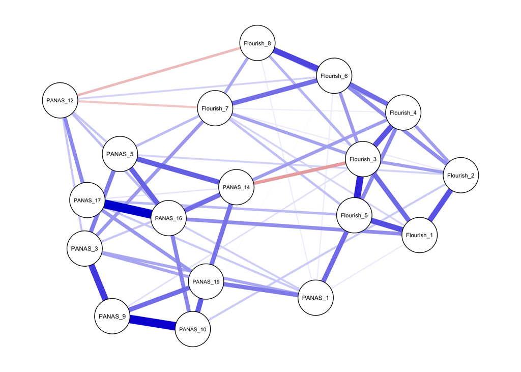

```r
plot(network_model1)
```

#flourishing and AHS (Adult Hope Scale)

```r
network_data2 <- PPI_dataset[, c("AHS_1", "AHS_2", "AHS_3", "AHS_4", "AHS_5", "AHS_6", "AHS_7", "AHS_8", "AHS_9",  "AHS_10", "AHS_11", "Flourish_1", "Flourish_2", "Flourish_3", "Flourish_4", "Flourish_5", "Flourish_6", "Flourish_7", "Flourish_8")]


network_data2 <-na.omit(network_data2)
network_data2 <- network_data2[, sapply(network_data2, function(x) sd(x, na.rm = TRUE) != 0)]

library(bootnet)
library(qgraph)
library(dplyr)

network_model2 <- estimateNetwork(network_data2,
                                  default = "EBICglasso",
                                  corMethod = "cor")
```

```
## Estimating Network. Using package::function:
##   - qgraph::EBICglasso for EBIC model selection
##     - using glasso::glasso
```

```
## An empty network was selected to be the best fitting network. Possibly set 'lambda.min.ratio' higher to search more sparse networks. You can also change the 'gamma' parameter to improve sensitivity (at the cost of specificity).
```

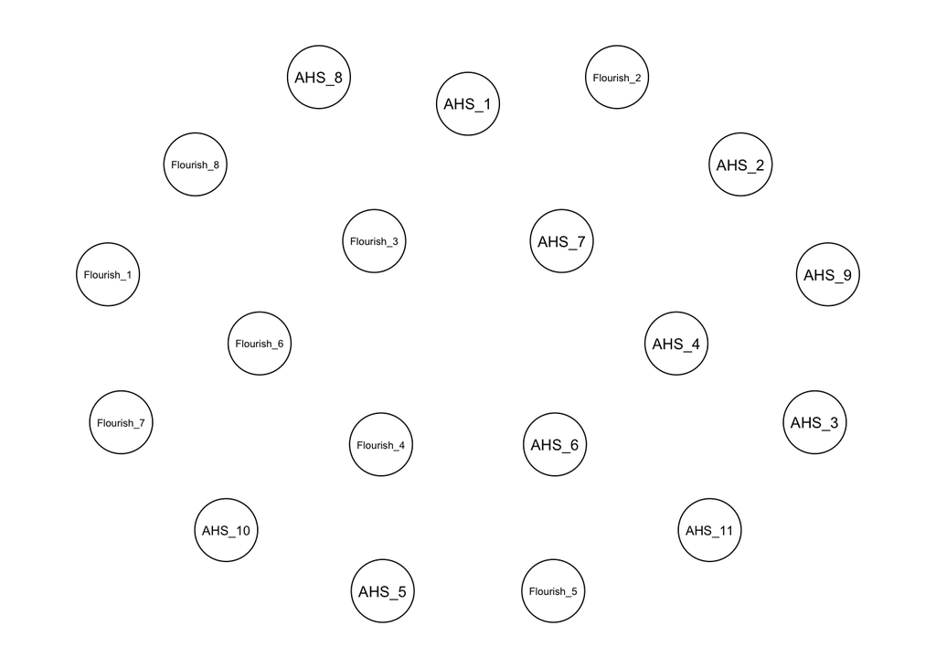

```r
plot(network_model2)
```

“An empty network was selected to be the best fitting network.” –> What should I do to solve this problem?

#CESD recoding evaluation

```r
# 1. select only necessary variables
cesd_vars <- PPI_dataset %>%
  select(CESD_PreTotal, CESD_5, CESD_8)

# 2.correlation test
cor.test(cesd_vars$CESD_5, cesd_vars$CESD_PreTotal)  # CESD_5 vs Total
```

```
##
##  Pearson's product-moment correlation
##
## data:  cesd_vars$CESD_5 and cesd_vars$CESD_PreTotal
## t = 8.8139, df = 81, p-value = 1.854e-13
## alternative hypothesis: true correlation is not equal to 0
## 95 percent confidence interval:
##  0.5700169 0.7953434
## sample estimates:
##       cor
## 0.6996826
```

```r
cor.test(cesd_vars$CESD_8, cesd_vars$CESD_PreTotal)  # CESD_8 vs Total
```

```
##
##  Pearson's product-moment correlation
##
## data:  cesd_vars$CESD_8 and cesd_vars$CESD_PreTotal
## t = 13.49, df = 81, p-value < 2.2e-16
## alternative hypothesis: true correlation is not equal to 0
## 95 percent confidence interval:
##  0.750896 0.888186
## sample estimates:
##       cor
## 0.8318575
```

```r
# make new recoded variables
cesd_vars <- cesd_vars %>%
  mutate(
    CESD_5_R = 3 - CESD_5,
    CESD_8_R = 3 - CESD_8
  )

# recheck the correlation
cor.test(cesd_vars$CESD_5_R, cesd_vars$CESD_PreTotal)
```

```
##
##  Pearson's product-moment correlation
##
## data:  cesd_vars$CESD_5_R and cesd_vars$CESD_PreTotal
## t = -8.8139, df = 81, p-value = 1.854e-13
## alternative hypothesis: true correlation is not equal to 0
## 95 percent confidence interval:
##  -0.7953434 -0.5700169
## sample estimates:
##        cor
## -0.6996826
```

```r
cor.test(cesd_vars$CESD_8_R, cesd_vars$CESD_PreTotal)
```

```
##
##  Pearson's product-moment correlation
##
## data:  cesd_vars$CESD_8_R and cesd_vars$CESD_PreTotal
## t = -13.49, df = 81, p-value < 2.2e-16
## alternative hypothesis: true correlation is not equal to 0
## 95 percent confidence interval:
##  -0.888186 -0.750896
## sample estimates:
##        cor
## -0.8318575
```

# Based on the correlation analyses, both CESD_5 and CESD_8 show strong positive correlations with the total CES-D score (CESD_PreTotal), while their reverse-coded versions (CESD_5_R and CESD_8_R) show strong negative correlations.

# This pattern indicates that the original CESD_5 and CESD_8 variables were already reverse-coded in the raw dataset. Applying reverse coding again (3 - x) in this case results in inverting the intended direction, leading to an incorrect interpretation.

# Therefore, reverse coding is not necessary, as the original variables are already in the correct (reverse-coded) format.

#flourishing and CESD (Depression)

```r
network_data3 <- PPI_dataset[, c("CESD_1", "CESD_2", "CESD_3", "CESD_4", "CESD_5",
  "CESD_6", "CESD_7", "CESD_8", "CESD_9", "CESD_10", "Flourish_1", "Flourish_2", "Flourish_3", "Flourish_4", "Flourish_5", "Flourish_6", "Flourish_7", "Flourish_8")]


network_data3 <-na.omit(network_data3)
network_data3 <- network_data3[, sapply(network_data3, function(x) sd(x, na.rm = TRUE) != 0)]

library(bootnet)
library(qgraph)
library(dplyr)

network_model3 <- estimateNetwork(network_data3,
                                  default = "EBICglasso",
                                  corMethod = "cor_auto")
```

```
## Estimating Network. Using package::function:
##   - qgraph::EBICglasso for EBIC model selection
##     - using glasso::glasso
##   - qgraph::cor_auto for correlation computation
##     - using lavaan::lavCor
```

```
## Variables detected as ordinal: CESD_1; CESD_2; CESD_3; CESD_4; CESD_5; CESD_6; CESD_7; CESD_8; CESD_9; CESD_10; Flourish_1; Flourish_2; Flourish_3; Flourish_4; Flourish_5; Flourish_6; Flourish_7; Flourish_8
```

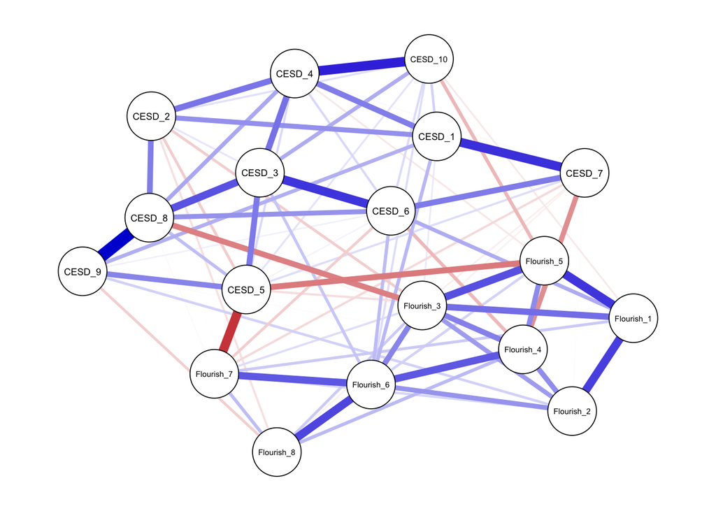

```r
plot(network_model3)
```

#flourishing and Autonomy

```r
network_data4 <- PPI_dataset[, c("PsyNeed_1",  "PsyNeed_7", "PsyNeed_13", "PsyNeed_19", "Flourish_1", "Flourish_2", "Flourish_3", "Flourish_4", "Flourish_5", "Flourish_6", "Flourish_7", "Flourish_8")]


network_data4 <-na.omit(network_data4)
network_data4 <- network_data4[, sapply(network_data4, function(x) sd(x, na.rm = TRUE) != 0)]

library(bootnet)
library(qgraph)
library(dplyr)

network_model4 <- estimateNetwork(network_data4,
                                  default = "EBICglasso",
                                  corMethod = "cor_auto")
```

```
## Estimating Network. Using package::function:
##   - qgraph::EBICglasso for EBIC model selection
##     - using glasso::glasso
##   - qgraph::cor_auto for correlation computation
##     - using lavaan::lavCor
```

```
## Variables detected as ordinal: PsyNeed_1; PsyNeed_7; PsyNeed_13; PsyNeed_19; Flourish_1; Flourish_2; Flourish_3; Flourish_4; Flourish_5; Flourish_6; Flourish_7; Flourish_8
```

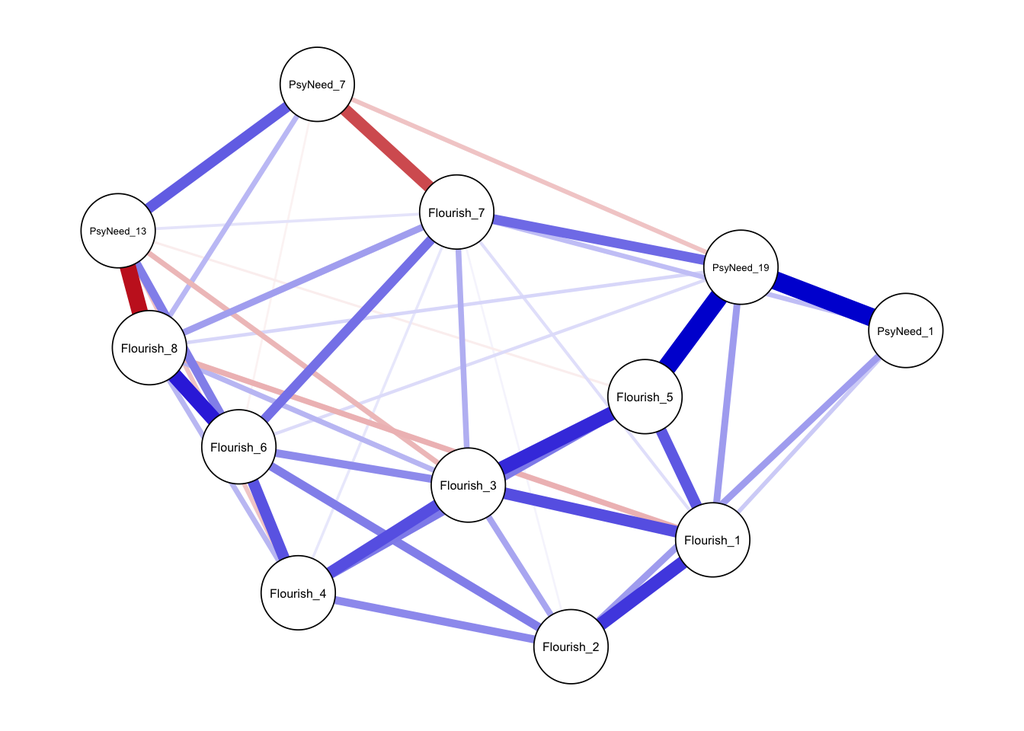

```r
plot(network_model4)
```

#flourishing and Relatedness

```r
network_data5 <- PPI_dataset[, c("PsyNeed_3",  "PsyNeed_9", "PsyNeed_15", "PsyNeed_21", "Flourish_1", "Flourish_2", "Flourish_3", "Flourish_4", "Flourish_5", "Flourish_6", "Flourish_7", "Flourish_8")]

network_data5 <-na.omit(network_data5)
network_data5 <- network_data5[, sapply(network_data5, function(x) sd(x, na.rm = TRUE) != 0)]

library(bootnet)
library(qgraph)
library(dplyr)

network_model5 <- estimateNetwork(network_data5,
                                  default = "EBICglasso",
                                  corMethod = "cor_auto")
```

```
## Estimating Network. Using package::function:
##   - qgraph::EBICglasso for EBIC model selection
##     - using glasso::glasso
##   - qgraph::cor_auto for correlation computation
##     - using lavaan::lavCor
```

```
## Variables detected as ordinal: PsyNeed_3; PsyNeed_9; PsyNeed_15; PsyNeed_21; Flourish_1; Flourish_2; Flourish_3; Flourish_4; Flourish_5; Flourish_6; Flourish_7; Flourish_8
```

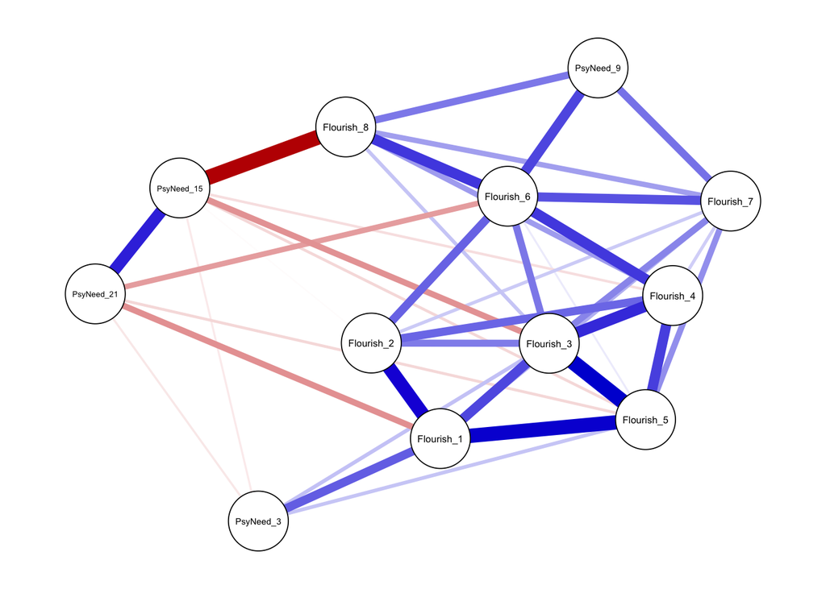

```r
plot(network_model5)
```

#flourishing and Competence

```r
network_data6 <- PPI_dataset[, c("PsyNeed_5",  "PsyNeed_11", "PsyNeed_17", "PsyNeed_23", "Flourish_1", "Flourish_2", "Flourish_3", "Flourish_4", "Flourish_5", "Flourish_6", "Flourish_7", "Flourish_8")]


network_data6 <-na.omit(network_data6)
network_data6 <- network_data6[, sapply(network_data6, function(x) sd(x, na.rm = TRUE) != 0)]

library(bootnet)
library(qgraph)
library(dplyr)

network_model6 <- estimateNetwork(network_data6,
                                  default = "EBICglasso",
                                  corMethod = "cor_auto")
```

```
## Estimating Network. Using package::function:
##   - qgraph::EBICglasso for EBIC model selection
##     - using glasso::glasso
##   - qgraph::cor_auto for correlation computation
##     - using lavaan::lavCor
```

```
## Variables detected as ordinal: PsyNeed_5; PsyNeed_11; PsyNeed_17; PsyNeed_23; Flourish_1; Flourish_2; Flourish_3; Flourish_4; Flourish_5; Flourish_6; Flourish_7; Flourish_8
```

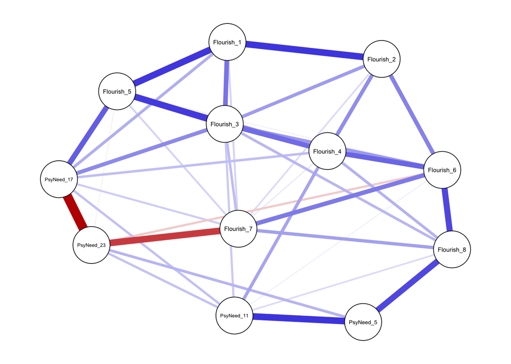

```r
plot(network_model6)
```